# Relat?rio - An?lise explorat?ria e descritiva do TravisTorrent

```r
library(tidyverse)
library(here)
library(knitr)
theme_set(theme_bw())
```

```r
projetos = read_csv(here::here("data/projetos.csv"))
cols(
  gh_project_name = col_character(),
  team = col_double(),
  lang = col_character(),
  sloc_end = col_integer(),
  sloc_med = col_double(),
  activity_period = col_integer(),
  num_commits = col_integer(),
  commits_per_month = col_double(),
  tests_per_kloc = col_double(),
  total_builds = col_integer(),
  build_success_prop = col_double(),
  builds_per_month = col_double(),
  tests_added_per_build = col_double(),
  tests_successful = col_double(),
  test_density = col_double(),
  test_size_avg = col_double()
)
projetos = projetos %>%
    filter(lang != "javascript")
```

===== Vari?vel: Equipe Quantidade de integrantes por projeto

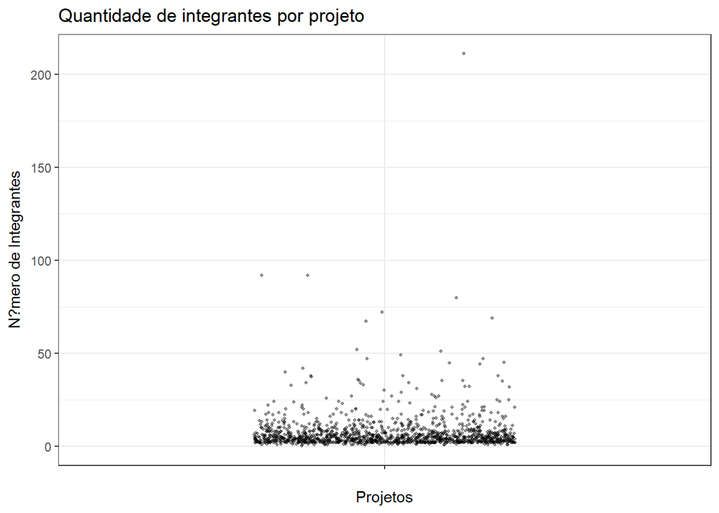

```r
projetos %>%
    ggplot(aes(x = "", y = team)) +
    geom_jitter(alpha = 0.4, width = 0.2, size = 0.8) +
    ylab("N?mero de Integrantes") +
    ggtitle("Quantidade de integrantes por projeto") +
    xlab("Projetos")
```

Tamanho das equipes por linguagem de programa??o

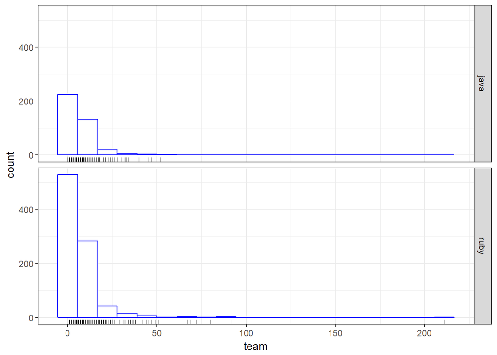

```r
projetos %>%
    ggplot(aes(x = team)) +
    geom_histogram(bins = 20, fill = "white", color = "blue") +
    geom_rug(alpha = .3) +
    facet_grid(lang ~ .)
```

N?mero de projetos pela quantidade de integrantes

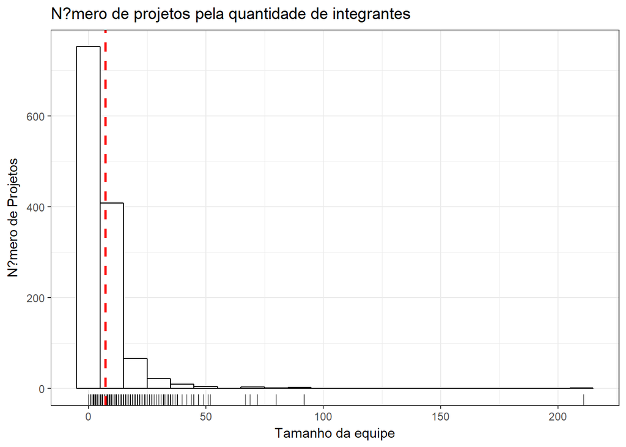

```r
projetos %>%
    ggplot(mapping = aes(x = team)) +
    geom_histogram(bins = 20, binwidth = 10, colour="black", fill="white") +
    geom_rug(alpha = 0.5) +
    ylab("N?mero de Projetos") +
    xlab("Tamanho da equipe") +
    ggtitle("N?mero de projetos pela quantidade de integrantes") +
    geom_vline(aes(xintercept=mean(team, na.rm=T)),color="red", linetype="dashed", size=1)
```

===== Vari?vel: linguagem de programa??o Quantidade de projetos pela linguagem de programa??o

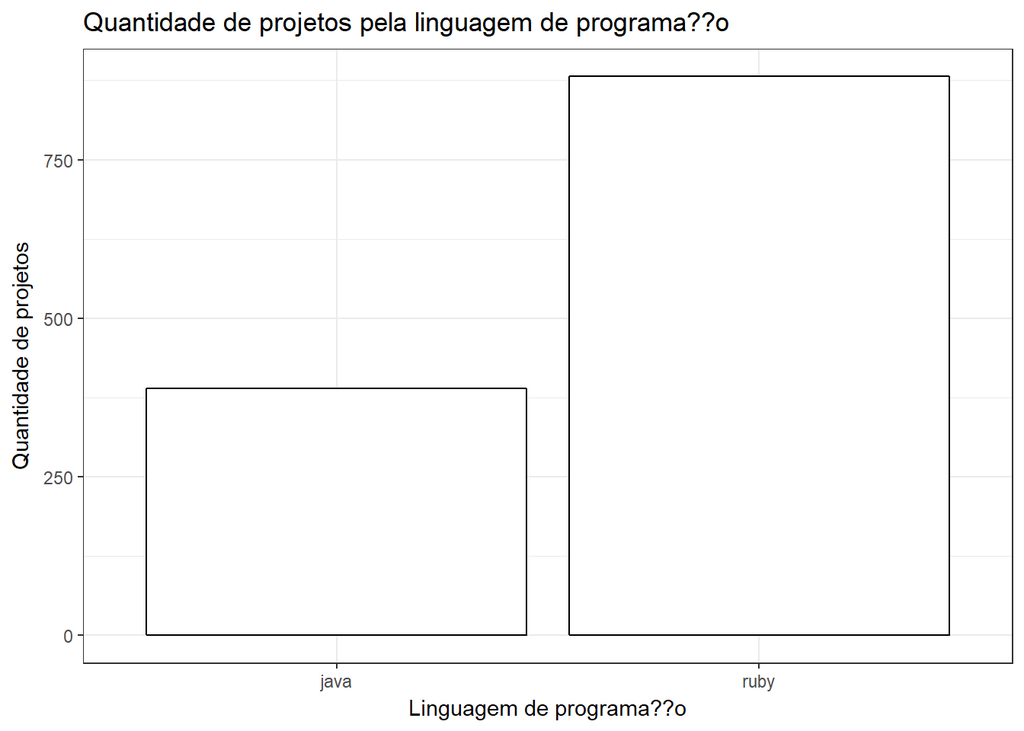

```r
projetos %>%
    group_by(lang) %>%
    summarise(n = n()) %>%
    ggplot(aes(x = lang, y = n)) +
    geom_col(colour="black", fill="white", show.legend = TRUE) +
    ylab("Quantidade de projetos") +
    xlab("Linguagem de programa??o") +
    ggtitle("Quantidade de projetos pela linguagem de programa??o")
```

Equipes por linguagem de programa??o

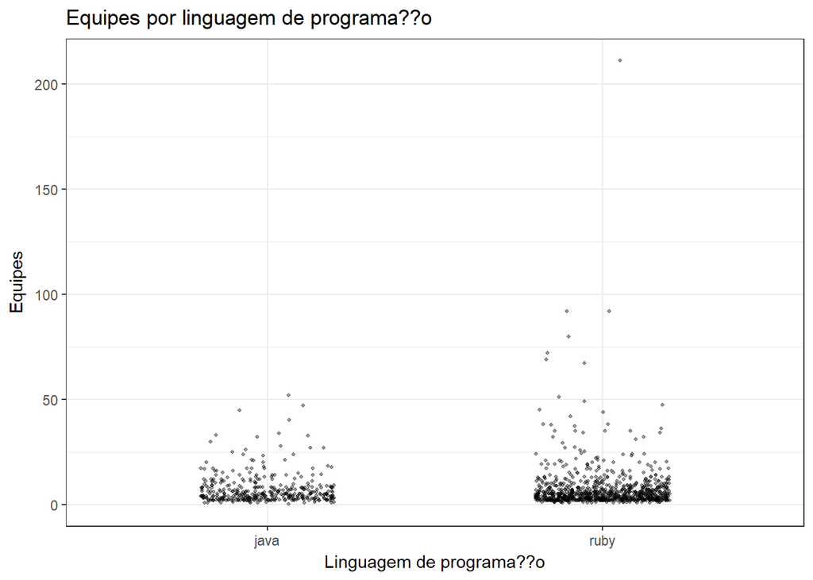

```r
projetos %>%
    ggplot(aes(x = lang, y = team)) +
    geom_jitter(alpha = .4, width = .2, size = .8) +
    ylab("Equipes") +
    xlab("Linguagem de programa??o") +
    ggtitle("Equipes por linguagem de programa??o")
```

===== vari?vel: builds de sucesso

Quantidade de builds de sucesso por linguagem de programa??o

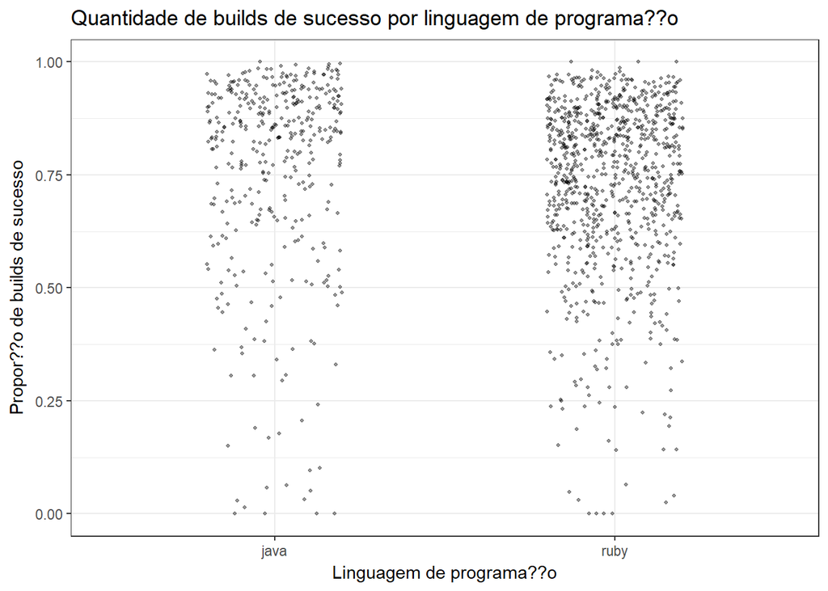

```r
projetos %>%
    ggplot(aes(x = lang, y = build_success_prop)) +
    geom_jitter(alpha = 0.4, width = 0.2, size = 0.8) +
    ylab("Propor??o de builds de sucesso") +
    ggtitle("Quantidade de builds de sucesso por linguagem de programa??o") +
    xlab("Linguagem de programa??o")
```

Propo??o de builds de sucesso por linguagem de programa??o

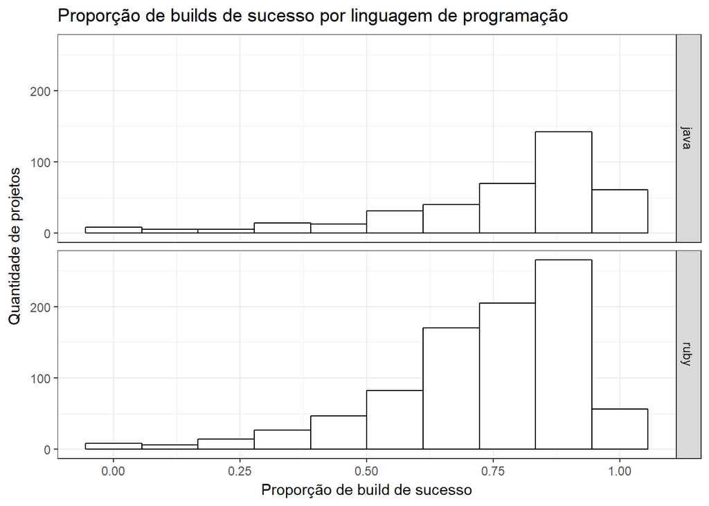

```r
projetos %>%
    ggplot(aes(x= build_success_prop)) +
    geom_histogram(bins = 10, colour="black", fill="white") +
    facet_grid(lang ~ .) +
    ylab("Quantidade de projetos") +
    xlab("Proporção de build de sucesso") +
    ggtitle("Proporção de builds de sucesso por linguagem de programação")
```

===== vari?vel: Commits Quantidade de commits pela linguagem de programa??o

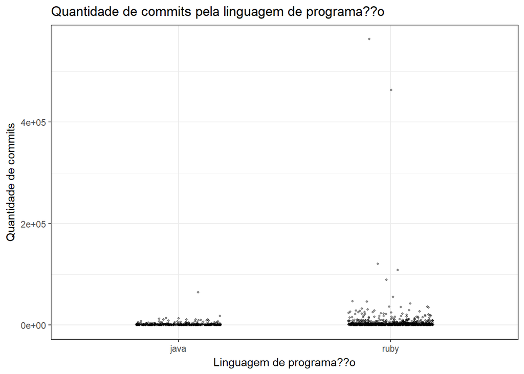

```r
projetos %>%
    ggplot(aes(x = lang, y = num_commits)) +
    geom_jitter(alpha = 0.4, width = 0.2, size = 0.8) +
    ylab("Quantidade de commits") +
    ggtitle("Quantidade de commits pela linguagem de programa??o") +
    xlab("Linguagem de programa??o")
```

Total Commits por linguagem de programa??o

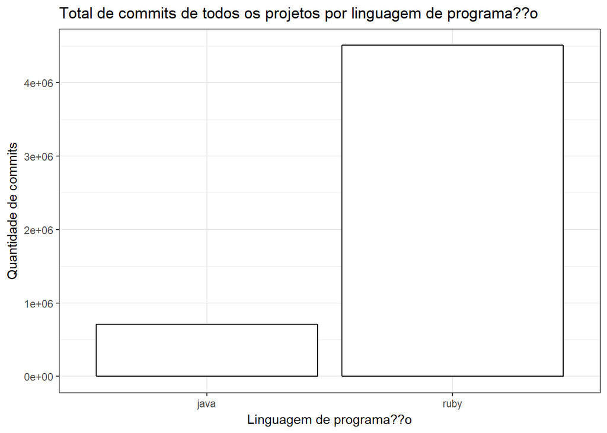

```r
projetos %>%
  group_by(lang) %>%
  summarise(total = sum(num_commits)) %>%
  arrange(total) %>%
  ggplot(aes(x = lang, y = total)) +
  geom_col(colour="black", fill="white") +
  ylab("Quantidade de commits") +
  xlab("Linguagem de programa??o") +
  ggtitle("Total de commits de todos os projetos por linguagem de programa??o")
```

Quantidade de commits pelo tamanho da equipe

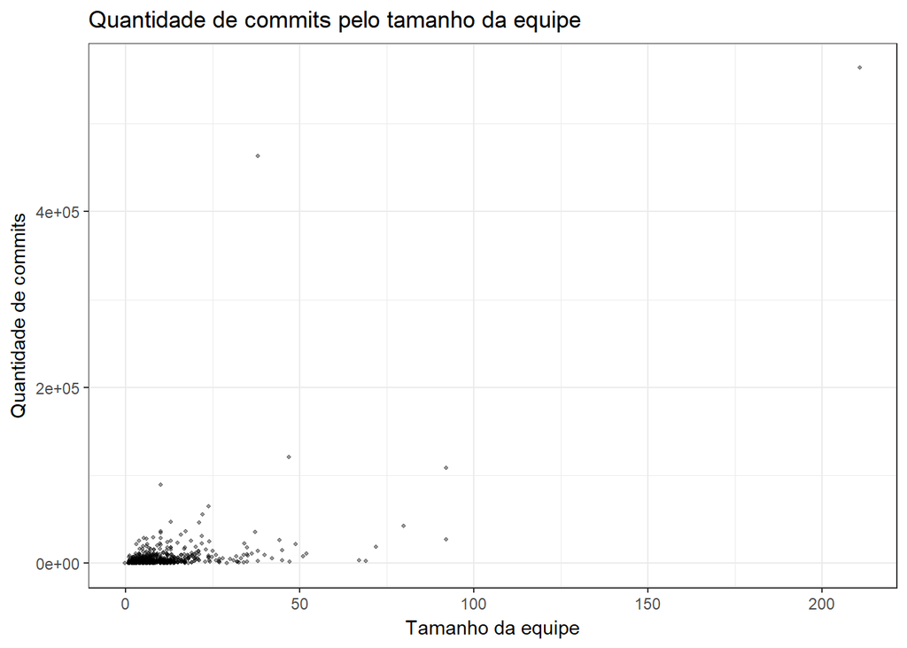

```r
projetos %>%
    ggplot(aes(x = team, y = num_commits)) +
    geom_jitter(alpha = 0.4, width = 0.2, size = 0.8) +
    ylab("Quantidade de commits") +
    ggtitle("Quantidade de commits pelo tamanho da equipe") +
    xlab("Tamanho da equipe")
```

N?mero de commits pelo tamanho da equipe

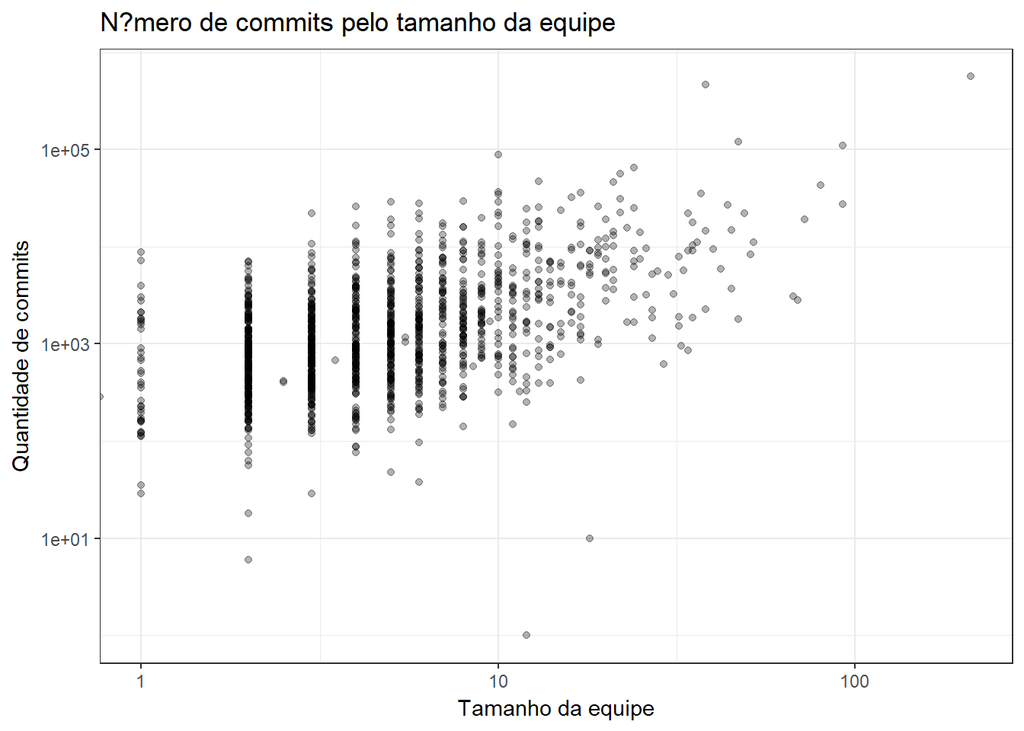

```r
projetos %>%
    ggplot(aes(x = team,
               y = num_commits)) +
    geom_point(alpha = .3) +
    scale_x_log10() +
    scale_y_log10() +
    ylab("Quantidade de commits") +
    xlab("Tamanho da equipe") +
    ggtitle("N?mero de commits pelo tamanho da equipe")
```

N?mero de projetos pelo total de commits e linguagem de programa??o

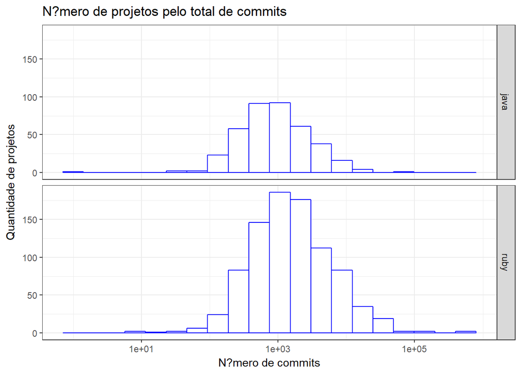

```r
projetos %>%
    ggplot(aes(x = num_commits)) +
    geom_histogram(bins = 20, fill = "white", color = "blue") +
    facet_grid(lang ~ .) +
    scale_x_log10() +
    ylab("Quantidade de projetos") +
    xlab("N?mero de commits") +
    ggtitle("N?mero de projetos pelo total de commits")
```

N?mero de commits pela propor??o de builds de sucesso

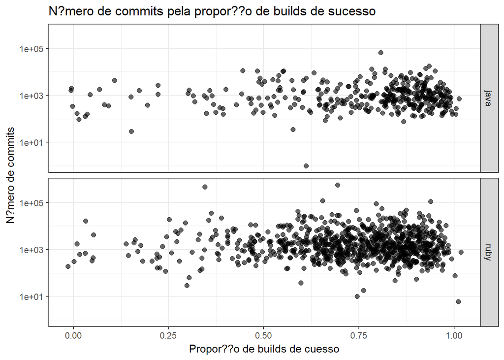

```r
projetos %>%
  ggplot(aes(x = build_success_prop, y = num_commits)) +
    geom_jitter(width = .02, height = 0, size = 2, alpha = .6) +
    facet_grid(lang ~ .) +
    scale_y_log10() +
    ylab("N?mero de commits") +
    xlab("Propor??o de builds de cuesso") +
    ggtitle("N?mero de commits pela propor??o de builds de sucesso")
```

PERGUNTAS PERGUNTA 1.0 - Em equipes com menos de 10 membros, projetos de qual linguagem variam mais na propor?ao de builds de sucesso

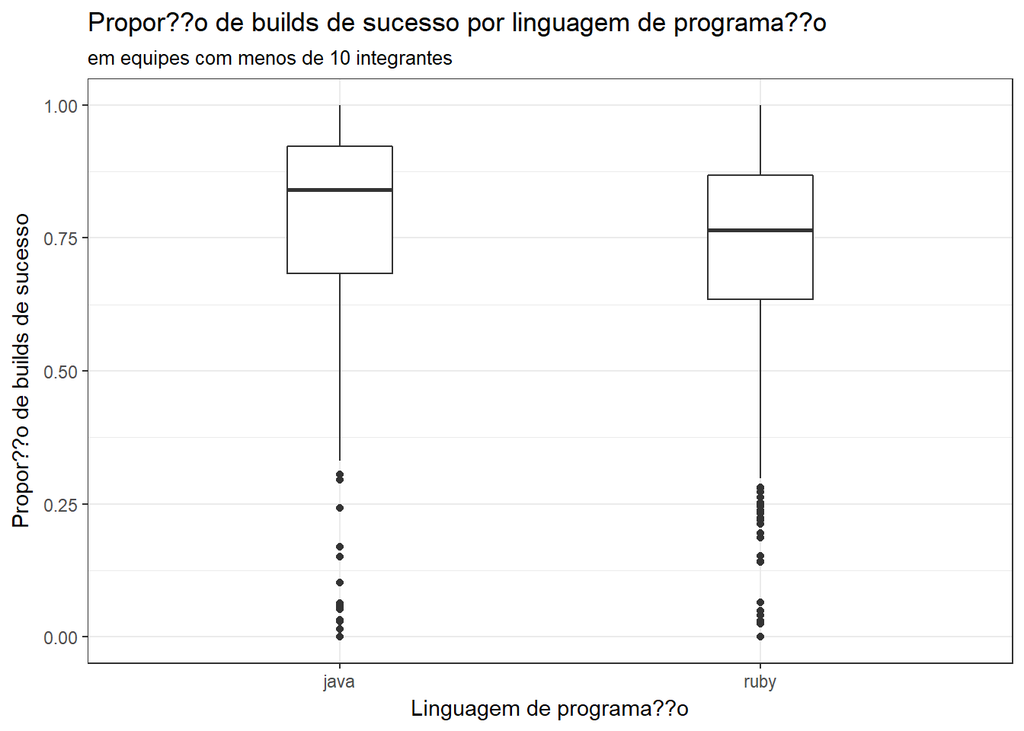

```r
projetos %>%
    filter(team < 10) %>%
    ggplot(aes(x= lang,  y = build_success_prop)) +
    geom_boxplot(width = .25) +
    ylab("Propor??o de builds de sucesso") +
    xlab("Linguagem de programa??o") +
    ggtitle("Propor??o de builds de sucesso por linguagem de programa??o", subtitle ="em equipes com menos de 10 integrantes" )
```

Builds de sucesso por linguagem de programa??o - equipes menos de 10

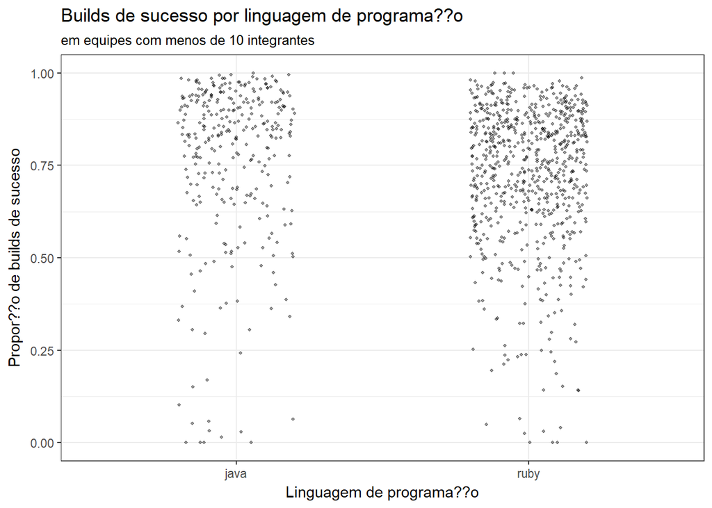

```r
projetos %>%
    filter(team < 10) %>%
    ggplot(aes(x = lang, y = build_success_prop)) +
    geom_jitter(alpha = .4, width = .2, size = .8) +
    ylab("Propor??o de builds de sucesso") +
    xlab("Linguagem de programa??o") +
    ggtitle("Builds de sucesso por linguagem de programa??o", subtitle ="em equipes com menos de 10 integrantes" )
```

PERGUNTA 1.1 - Em equipes com 10 ou mais membros, projetos de qual linguagem variam mais na propor?ao de builds de sucesso

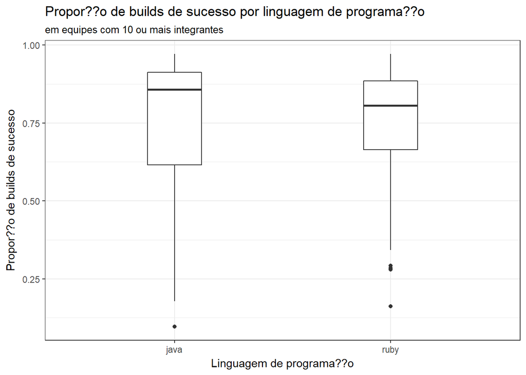

```r
projetos %>%
    filter(team >= 10) %>%
    ggplot(aes(x= lang,  y = build_success_prop)) +
    geom_boxplot(width = .25) +
    ylab("Propor??o de builds de sucesso") +
    xlab("Linguagem de programa??o") +
    ggtitle("Propor??o de builds de sucesso por linguagem de programa??o", subtitle ="em equipes com 10 ou mais integrantes" )
```

Builds de sucesso por linguagem de programa??o - equipes com 10 ou mais

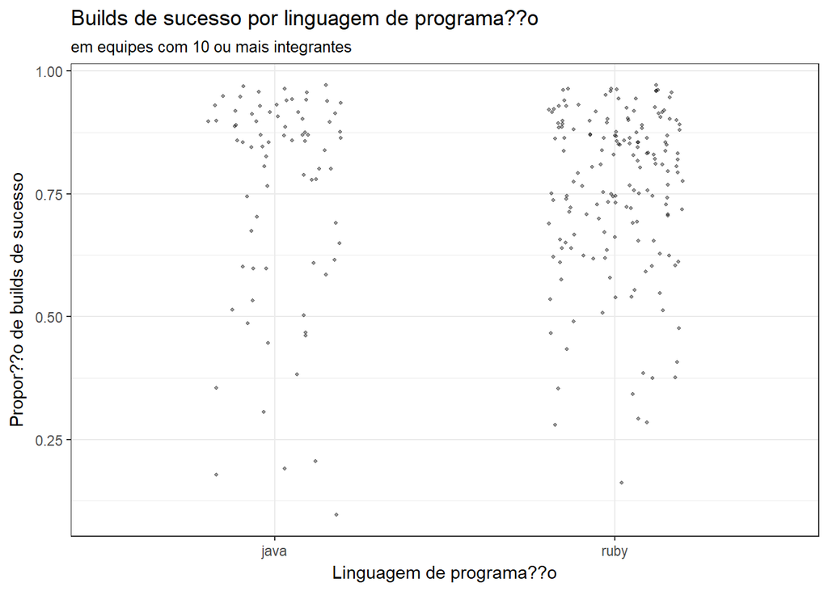

```r
projetos %>%
    filter(team >= 10) %>%
    ggplot(aes(x = lang, y = build_success_prop)) +
    geom_jitter(alpha = .4, width = .2, size = .8) +
    ylab("Propor??o de builds de sucesso") +
    xlab("Linguagem de programa??o") +
    ggtitle("Builds de sucesso por linguagem de programa??o", subtitle ="em equipes com 10 ou mais integrantes" )
```

Pergunta 1-final: Comparar projetos em java e ruby que tenham aos menos 10 integrantes. Comparar em rela??o a varia??o na propor??o de buids que s?o sucesso

Propor??o de builds pror tamanho de grupo - contagem

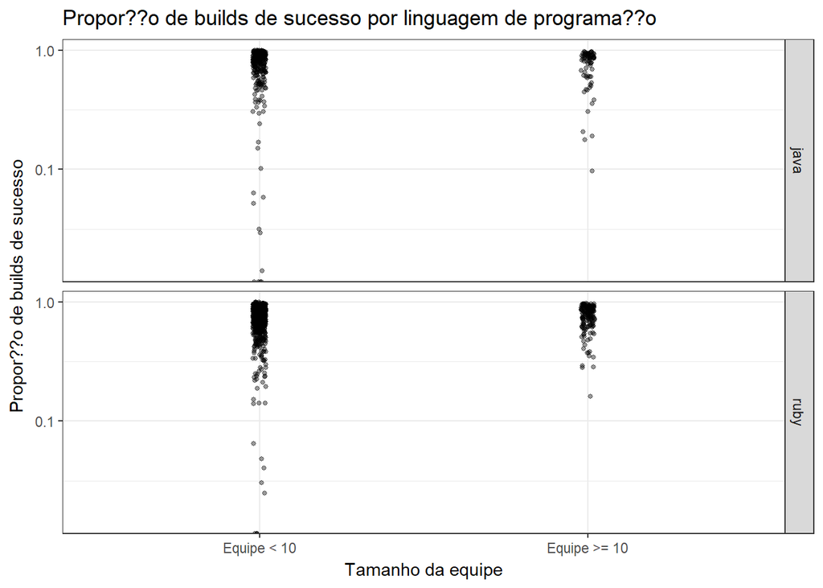

```r
a = projetos %>%
    filter(team >= 10) %>%
    within(w <- "Equipe >= 10")

b = projetos %>%
    filter(team < 10) %>%
    within(w <- "Equipe < 10")

resultados <- bind_rows(a, b)

resultados %>%
  ggplot(aes(x = w, y=build_success_prop)) +
    geom_jitter(width = .02, height = 0, size = 1, alpha = .4) +
    facet_grid(lang ~ .) +
    scale_y_log10() +
    ylab("Propor??o de builds de sucesso") +
    xlab("Tamanho da equipe") +
    ggtitle("Propor??o de builds de sucesso por linguagem de programa??o")
```

Propor??o de builds pror tamanho de grupo - boxplot

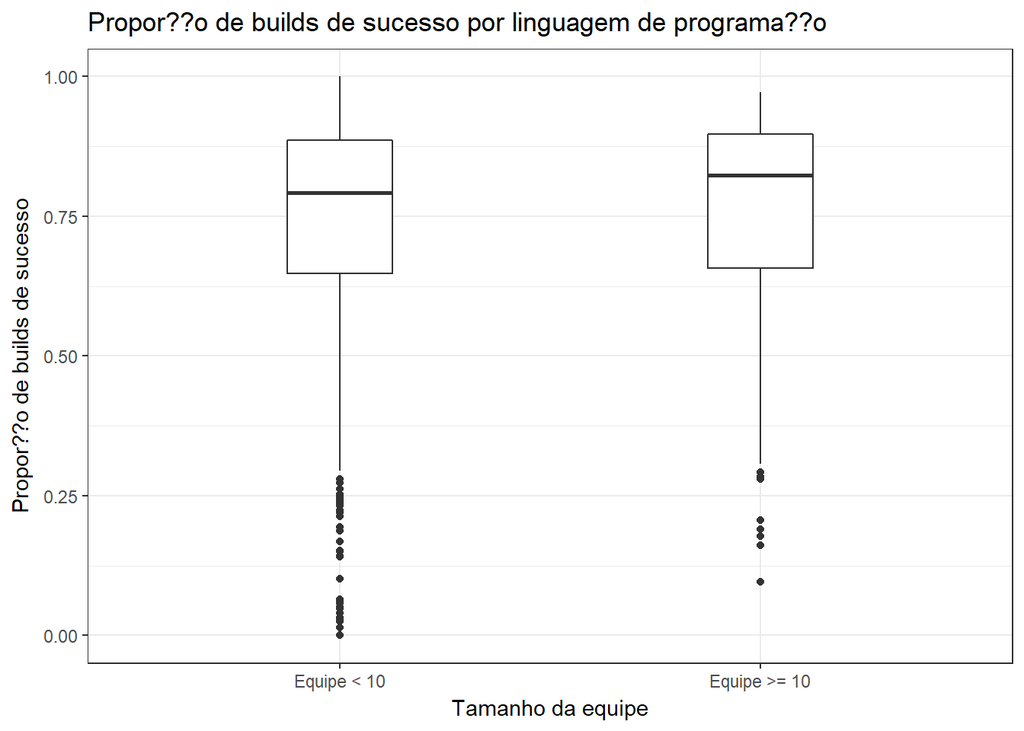

```r
a = projetos %>%
    filter(team >= 10) %>%
    within(w <- "Equipe >= 10")

b = projetos %>%
    filter(team < 10) %>%
    within(w <- "Equipe < 10")

resultados <- bind_rows(a, b)


resultados %>%
    ggplot(aes(x= w,  y = build_success_prop)) +
    geom_boxplot(width = .25) +
    ylab("Propor??o de builds de sucesso") +
    xlab("Tamanho da equipe") +
    ggtitle("Propor??o de builds de sucesso por linguagem de programa??o")
```